# Table de matière

```python
import pandas as pd
import matplotlib.pyplot as plt
import seaborn as sns
import numpy as np
from sklearn.cluster import KMeans
from sklearn import decomposition, preprocessing, linear_model
from sklearn.metrics import confusion_matrix, classification_report
from sklearn.model_selection import train_test_split
from sklearn import neighbors
from sklearn.metrics import accuracy_score, r2_score
import statsmodels.api as sm
```

# Importation des données

```python
# Importation des données
data = pd.read_csv(
    'Desktop/Openclassrooms/P10_Shibin_YANG/billets.csv', sep=';')
```

```python
data
```

|  | is_genuine | diagonal | height_left | height_right | margin_low | margin_up | length |
| --- | --- | --- | --- | --- | --- | --- | --- |
| 0 | True | 171.81 | 104.86 | 104.95 | 4.52 | 2.89 | 112.83 |
| 1 | True | 171.46 | 103.36 | 103.66 | 3.77 | 2.99 | 113.09 |
| 2 | True | 172.69 | 104.48 | 103.50 | 4.40 | 2.94 | 113.16 |
| 3 | True | 171.36 | 103.91 | 103.94 | 3.62 | 3.01 | 113.51 |
| 4 | True | 171.73 | 104.28 | 103.46 | 4.04 | 3.48 | 112.54 |
| ... | ... | ... | ... | ... | ... | ... | ... |
| 1495 | False | 171.75 | 104.38 | 104.17 | 4.42 | 3.09 | 111.28 |
| 1496 | False | 172.19 | 104.63 | 104.44 | 5.27 | 3.37 | 110.97 |
| 1497 | False | 171.80 | 104.01 | 104.12 | 5.51 | 3.36 | 111.95 |
| 1498 | False | 172.06 | 104.28 | 104.06 | 5.17 | 3.46 | 112.25 |
| 1499 | False | 171.47 | 104.15 | 103.82 | 4.63 | 3.37 | 112.07 |

1500 rows × 7 columns

```python
# Valeur manquante pour la variable 'margin_low'
data.info()
```

```
<class 'pandas.core.frame.DataFrame'>
RangeIndex: 1500 entries, 0 to 1499
Data columns (total 7 columns):
 #   Column        Non-Null Count  Dtype
---  ------        --------------  -----
 0   is_genuine    1500 non-null   bool
 1   diagonal      1500 non-null   float64
 2   height_left   1500 non-null   float64
 3   height_right  1500 non-null   float64
 4   margin_low    1463 non-null   float64
 5   margin_up     1500 non-null   float64
 6   length        1500 non-null   float64
dtypes: bool(1), float64(6)
memory usage: 71.9 KB
```

```python
# Vérification des lignes qui ont les valeurs manquantes dans la colonne margin_low
Null = data[data['margin_low'].isnull()]
Null
```

|  | is_genuine | diagonal | height_left | height_right | margin_low | margin_up | length |
| --- | --- | --- | --- | --- | --- | --- | --- |
| 72 | True | 171.94 | 103.89 | 103.45 | NaN | 3.25 | 112.79 |
| 99 | True | 171.93 | 104.07 | 104.18 | NaN | 3.14 | 113.08 |
| 151 | True | 172.07 | 103.80 | 104.38 | NaN | 3.02 | 112.93 |
| 197 | True | 171.45 | 103.66 | 103.80 | NaN | 3.62 | 113.27 |
| 241 | True | 171.83 | 104.14 | 104.06 | NaN | 3.02 | 112.36 |
| 251 | True | 171.80 | 103.26 | 102.82 | NaN | 2.95 | 113.22 |
| 284 | True | 171.92 | 103.83 | 103.76 | NaN | 3.23 | 113.29 |
| 334 | True | 171.85 | 103.70 | 103.96 | NaN | 3.00 | 113.36 |
| 410 | True | 172.56 | 103.72 | 103.51 | NaN | 3.12 | 112.95 |
| 413 | True | 172.30 | 103.66 | 103.50 | NaN | 3.16 | 112.95 |
| 445 | True | 172.34 | 104.42 | 103.22 | NaN | 3.01 | 112.97 |
| 481 | True | 171.81 | 103.53 | 103.96 | NaN | 2.71 | 113.99 |
| 505 | True | 172.01 | 103.97 | 104.05 | NaN | 2.98 | 113.65 |
| 611 | True | 171.80 | 103.68 | 103.49 | NaN | 3.30 | 112.84 |
| 654 | True | 171.97 | 103.69 | 103.54 | NaN | 2.70 | 112.79 |
| 675 | True | 171.60 | 103.85 | 103.91 | NaN | 2.56 | 113.27 |
| 710 | True | 172.03 | 103.97 | 103.86 | NaN | 3.07 | 112.65 |
| 739 | True | 172.07 | 103.74 | 103.76 | NaN | 3.09 | 112.41 |
| 742 | True | 172.14 | 104.06 | 103.96 | NaN | 3.24 | 113.07 |
| 780 | True | 172.41 | 103.95 | 103.79 | NaN | 3.13 | 113.41 |
| 798 | True | 171.96 | 103.84 | 103.62 | NaN | 3.01 | 114.44 |
| 844 | True | 171.62 | 104.14 | 104.49 | NaN | 2.99 | 113.35 |
| 845 | True | 172.02 | 104.21 | 104.05 | NaN | 2.90 | 113.62 |
| 871 | True | 171.37 | 104.07 | 103.75 | NaN | 3.07 | 113.27 |
| 895 | True | 171.81 | 103.68 | 103.80 | NaN | 2.98 | 113.82 |
| 919 | True | 171.92 | 103.68 | 103.45 | NaN | 2.58 | 113.68 |
| 945 | True | 172.09 | 103.74 | 103.52 | NaN | 3.02 | 112.78 |
| 946 | True | 171.63 | 103.87 | 104.66 | NaN | 3.27 | 112.68 |
| 981 | True | 172.02 | 104.23 | 103.72 | NaN | 2.99 | 113.37 |
| 1076 | False | 171.57 | 104.27 | 104.44 | NaN | 3.21 | 111.87 |
| 1121 | False | 171.40 | 104.38 | 104.19 | NaN | 3.17 | 112.39 |
| 1176 | False | 171.59 | 104.05 | 103.94 | NaN | 3.02 | 111.29 |
| 1303 | False | 172.17 | 104.49 | 103.76 | NaN | 2.93 | 111.21 |
| 1315 | False | 172.08 | 104.15 | 104.17 | NaN | 3.40 | 112.29 |
| 1347 | False | 171.72 | 104.46 | 104.12 | NaN | 3.61 | 110.31 |
| 1435 | False | 172.66 | 104.33 | 104.41 | NaN | 3.56 | 111.47 |
| 1438 | False | 171.90 | 104.28 | 104.29 | NaN | 3.24 | 111.49 |

# Nettoyage des données

## Vérification de corrélation entre les variables

```python
data.drop(columns=["is_genuine"]).corr()
```

|  | diagonal | height_left | height_right | margin_low | margin_up | length |
| --- | --- | --- | --- | --- | --- | --- |
| diagonal | 1.000000 | 0.019472 | -0.024492 | -0.111534 | -0.055649 | 0.097587 |
| height_left | 0.019472 | 1.000000 | 0.242279 | 0.302643 | 0.246522 | -0.320863 |
| height_right | -0.024492 | 0.242279 | 1.000000 | 0.391085 | 0.307005 | -0.401751 |
| margin_low | -0.111534 | 0.302643 | 0.391085 | 1.000000 | 0.431606 | -0.666753 |
| margin_up | -0.055649 | 0.246522 | 0.307005 | 0.431606 | 1.000000 | -0.520575 |
| length | 0.097587 | -0.320863 | -0.401751 | -0.666753 | -0.520575 | 1.000000 |

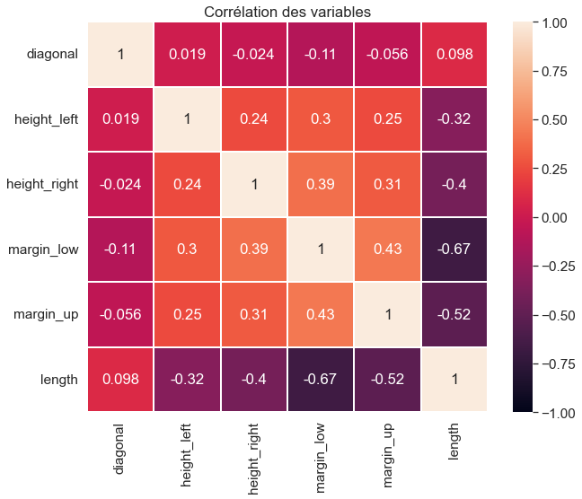

```python
sns.set(rc={'figure.figsize': (10, 8)}, font_scale=1.4)
sns.heatmap(data.drop(columns=["is_genuine"]).corr(
), linewidths=0.05, vmin=-1, vmax=1, annot=True)

plt.title('Corrélation des variables')
plt.show()
```

On fait d'abord vérifier s'il y a des corrélations entre les variables, s'il y en a, on peut appliquer la méthode de régression linéaire multivarié, afin pour remplacer les valeurs manquantes. On peut voir qu'il y a un peu de corrélation entre les variables, mais pas assez forte. On va quand même essayer avec le modèle de régression linéaire multivarié pour voir qu'est ce que cela donne.

## Création de modèle régression linéaire

### Régression linéaire avec la librairie Sklearn

```python
# Création de model régression linéaire multivarié pour déterminer les valeurs manquantes
Data_model = data.drop(Null.index)

X = Data_model.drop(columns=["is_genuine",'margin_low'])
Y = Data_model['margin_low']

X_train, X_test, Y_train, Y_test = train_test_split(
    X, Y, train_size=0.8, random_state=10)
```

```python
X_train.shape
```

```
(1170, 5)
```

```python
X_test.shape
```

```
(293, 5)
```

```python
lin_reg = linear_model.LinearRegression()
lin_reg.fit(X_train, Y_train)
```

```
LinearRegression()
```

```python
Y_predict = lin_reg.predict(X_test)
lin_reg.score(X_train, Y_train)
```

```
0.4606184927695156
```

```python
lin_reg.score(X_test, Y_test)
```

```
0.5404416684919964
```

En appliquant le model de régression linéaire, on a un coeffient de détermination à 46%, soit coefficient de détermination sur les données de test à 54%. Je trouve que le pouvoir de prédire de ce model n'est pas assez forte pour déterminer les valeurs manquantes. On va ajouter la variable 'is_genuine' qui distingue les vrais et faux billets pour vois si ce sera mieux.

```python
X = Data_model.drop(columns=['margin_low'])
Y = Data_model['margin_low']

X_train, X_test, Y_train, Y_test = train_test_split(
    X, Y, train_size=0.8, random_state=10)
lin_reg = linear_model.LinearRegression()
lin_reg.fit(X_train, Y_train)
```

```
LinearRegression()
```

```python
Y_predict = lin_reg.predict(X_test)
lin_reg.score(X_train, Y_train)
```

```
0.6093593674078632
```

```python
lin_reg.score(X_test, Y_test)
```

```
0.6429607879346595
```

J'essaie d'ajouter la variable 'is_genuine' qui distingue les vrais et faux billets, et refaire le modèle, donc, on a un coeffient de détermination à 61%, soit coefficient de détermination sur les données de test à 64%. C'est beaucoup mieux, même si ce n'est pas très élevé, mais il présente quand même une prédiction assez parlante.

### Régression linéaire avec la librairie Statsmodels

```python
X = Data_model.drop(columns=["is_genuine",'margin_low'])
Y = Data_model['margin_low']
X_train, X_test, Y_train, Y_test = train_test_split(
    X, Y, train_size=0.8, random_state=10)
X_train = sm.add_constant(X_train)
model = sm.OLS(Y_train, X_train)
result = model.fit()
print(result.summary())
```

```
                            OLS Regression Results
==============================================================================
Dep. Variable:             margin_low   R-squared:                       0.461
Model:                            OLS   Adj. R-squared:                  0.458
Method:                 Least Squares   F-statistic:                     198.8
Date:                Tue, 01 Mar 2022   Prob (F-statistic):          3.05e-153
Time:                        15:50:57   Log-Likelihood:                -815.42
No. Observations:                1170   AIC:                             1643.
Df Residuals:                    1164   BIC:                             1673.
Df Model:                           5
Covariance Type:            nonrobust
================================================================================
                   coef    std err          t      P>|t|      [0.025      0.975]
--------------------------------------------------------------------------------
const           24.3796     10.886      2.240      0.025       3.022      45.737
diagonal        -0.1207      0.047     -2.589      0.010      -0.212      -0.029
height_left      0.1932      0.051      3.771      0.000       0.093       0.294
height_right     0.2478      0.049      5.088      0.000       0.152       0.343
margin_up        0.2292      0.074      3.092      0.002       0.084       0.375
length          -0.4057      0.021    -19.656      0.000      -0.446      -0.365
==============================================================================
Omnibus:                       63.116   Durbin-Watson:                   2.009
Prob(Omnibus):                  0.000   Jarque-Bera (JB):               82.046
Skew:                           0.503   Prob(JB):                     1.53e-18
Kurtosis:                       3.819   Cond. No.                     1.93e+05
==============================================================================

Notes:
[1] Standard Errors assume that the covariance matrix of the errors is correctly specified.
[2] The condition number is large, 1.93e+05. This might indicate that there are
strong multicollinearity or other numerical problems.
```

```python
X = Data_model.drop(columns=['margin_low']).astype(float)
Y = Data_model['margin_low']
X_train, X_test, Y_train, Y_test = train_test_split(
    X, Y, train_size=0.8, random_state=10)
X_train = sm.add_constant(X_train)
model = sm.OLS(Y_train, X_train)
result = model.fit()
print(result.summary())
```

```
                            OLS Regression Results
==============================================================================
Dep. Variable:             margin_low   R-squared:                       0.609
Model:                            OLS   Adj. R-squared:                  0.607
Method:                 Least Squares   F-statistic:                     302.4
Date:                Tue, 01 Mar 2022   Prob (F-statistic):          2.63e-233
Time:                        15:50:57   Log-Likelihood:                -626.67
No. Observations:                1170   AIC:                             1267.
Df Residuals:                    1163   BIC:                             1303.
Df Model:                           6
Covariance Type:            nonrobust
================================================================================
                   coef    std err          t      P>|t|      [0.025      0.975]
--------------------------------------------------------------------------------
const            5.1527      9.313      0.553      0.580     -13.119      23.425
is_genuine      -1.1695      0.056    -21.043      0.000      -1.279      -1.060
diagonal        -0.0312      0.040     -0.781      0.435      -0.109       0.047
height_left      0.0369      0.044      0.833      0.405      -0.050       0.124
height_right     0.0071      0.043      0.165      0.869      -0.077       0.091
margin_up       -0.2526      0.067     -3.762      0.000      -0.384      -0.121
length           0.0150      0.027      0.565      0.572      -0.037       0.067
==============================================================================
Omnibus:                       17.180   Durbin-Watson:                   1.993
Prob(Omnibus):                  0.000   Jarque-Bera (JB):               28.498
Skew:                           0.070   Prob(JB):                     6.48e-07
Kurtosis:                       3.752   Cond. No.                     1.94e+05
==============================================================================

Notes:
[1] Standard Errors assume that the covariance matrix of the errors is correctly specified.
[2] The condition number is large, 1.94e+05. This might indicate that there are
strong multicollinearity or other numerical problems.
```

```python
X_test = sm.add_constant(X_test)
Y_predict = result.predict(X_test)
print("Le coefficient de détermination sur les données de test = {}%".format(
    round((r2_score(Y_test, Y_predict)*100), 2)))
```

```
Le coefficient de détermination sur les données de test = 64.3%
```

J'essaie d'utiliser la librairie Statsmodels pour faire une régression linéaire multivarié. On a le même résultat, un coeffient de détermination à 61%, soit une prédiction correcte sur les données de test à 64%. On va utiliser ce modèle pour déterminer les 37 valeurs manquantes.

## Remplacement des valeurs manquantes

```python
# Remplacement les valeurs manquantes par la prédiction du régression linéaire
VNan = Null.drop(columns=['margin_low'])
billets = data
billets.loc[Null.index,('margin_low')] = lin_reg.predict(VNan).round(2)
billets
```

|  | is_genuine | diagonal | height_left | height_right | margin_low | margin_up | length |
| --- | --- | --- | --- | --- | --- | --- | --- |
| 0 | True | 171.81 | 104.86 | 104.95 | 4.52 | 2.89 | 112.83 |
| 1 | True | 171.46 | 103.36 | 103.66 | 3.77 | 2.99 | 113.09 |
| 2 | True | 172.69 | 104.48 | 103.50 | 4.40 | 2.94 | 113.16 |
| 3 | True | 171.36 | 103.91 | 103.94 | 3.62 | 3.01 | 113.51 |
| 4 | True | 171.73 | 104.28 | 103.46 | 4.04 | 3.48 | 112.54 |
| ... | ... | ... | ... | ... | ... | ... | ... |
| 1495 | False | 171.75 | 104.38 | 104.17 | 4.42 | 3.09 | 111.28 |
| 1496 | False | 172.19 | 104.63 | 104.44 | 5.27 | 3.37 | 110.97 |
| 1497 | False | 171.80 | 104.01 | 104.12 | 5.51 | 3.36 | 111.95 |
| 1498 | False | 172.06 | 104.28 | 104.06 | 5.17 | 3.46 | 112.25 |
| 1499 | False | 171.47 | 104.15 | 103.82 | 4.63 | 3.37 | 112.07 |

1500 rows × 7 columns

```python
billets.info()
```

```
<class 'pandas.core.frame.DataFrame'>
RangeIndex: 1500 entries, 0 to 1499
Data columns (total 7 columns):
 #   Column        Non-Null Count  Dtype
---  ------        --------------  -----
 0   is_genuine    1500 non-null   bool
 1   diagonal      1500 non-null   float64
 2   height_left   1500 non-null   float64
 3   height_right  1500 non-null   float64
 4   margin_low    1500 non-null   float64
 5   margin_up     1500 non-null   float64
 6   length        1500 non-null   float64
dtypes: bool(1), float64(6)
memory usage: 71.9 KB
```

```python
# Vérification si les valeurs manquantes sont bien remplacées par une interpolation linéaire
billets.loc[Null.index]
```

|  | is_genuine | diagonal | height_left | height_right | margin_low | margin_up | length |
| --- | --- | --- | --- | --- | --- | --- | --- |
| 72 | True | 171.94 | 103.89 | 103.45 | 4.06 | 3.25 | 112.79 |
| 99 | True | 171.93 | 104.07 | 104.18 | 4.11 | 3.14 | 113.08 |
| 151 | True | 172.07 | 103.80 | 104.38 | 4.12 | 3.02 | 112.93 |
| 197 | True | 171.45 | 103.66 | 103.80 | 3.99 | 3.62 | 113.27 |
| 241 | True | 171.83 | 104.14 | 104.06 | 4.13 | 3.02 | 112.36 |
| 251 | True | 171.80 | 103.26 | 102.82 | 4.12 | 2.95 | 113.22 |
| 284 | True | 171.92 | 103.83 | 103.76 | 4.08 | 3.23 | 113.29 |
| 334 | True | 171.85 | 103.70 | 103.96 | 4.13 | 3.00 | 113.36 |
| 410 | True | 172.56 | 103.72 | 103.51 | 4.07 | 3.12 | 112.95 |
| 413 | True | 172.30 | 103.66 | 103.50 | 4.07 | 3.16 | 112.95 |
| 445 | True | 172.34 | 104.42 | 103.22 | 4.13 | 3.01 | 112.97 |
| 481 | True | 171.81 | 103.53 | 103.96 | 4.21 | 2.71 | 113.99 |
| 505 | True | 172.01 | 103.97 | 104.05 | 4.15 | 2.98 | 113.65 |
| 611 | True | 171.80 | 103.68 | 103.49 | 4.05 | 3.30 | 112.84 |
| 654 | True | 171.97 | 103.69 | 103.54 | 4.19 | 2.70 | 112.79 |
| 675 | True | 171.60 | 103.85 | 103.91 | 4.26 | 2.56 | 113.27 |
| 710 | True | 172.03 | 103.97 | 103.86 | 4.11 | 3.07 | 112.65 |
| 739 | True | 172.07 | 103.74 | 103.76 | 4.09 | 3.09 | 112.41 |
| 742 | True | 172.14 | 104.06 | 103.96 | 4.07 | 3.24 | 113.07 |
| 780 | True | 172.41 | 103.95 | 103.79 | 4.09 | 3.13 | 113.41 |
| 798 | True | 171.96 | 103.84 | 103.62 | 4.15 | 3.01 | 114.44 |
| 844 | True | 171.62 | 104.14 | 104.49 | 4.16 | 2.99 | 113.35 |
| 845 | True | 172.02 | 104.21 | 104.05 | 4.18 | 2.90 | 113.62 |
| 871 | True | 171.37 | 104.07 | 103.75 | 4.14 | 3.07 | 113.27 |
| 895 | True | 171.81 | 103.68 | 103.80 | 4.15 | 2.98 | 113.82 |
| 919 | True | 171.92 | 103.68 | 103.45 | 4.24 | 2.58 | 113.68 |
| 945 | True | 172.09 | 103.74 | 103.52 | 4.11 | 3.02 | 112.78 |
| 946 | True | 171.63 | 103.87 | 104.66 | 4.07 | 3.27 | 112.68 |
| 981 | True | 172.02 | 104.23 | 103.72 | 4.15 | 2.99 | 113.37 |
| 1076 | False | 171.57 | 104.27 | 104.44 | 5.26 | 3.21 | 111.87 |
| 1121 | False | 171.40 | 104.38 | 104.19 | 5.29 | 3.17 | 112.39 |
| 1176 | False | 171.59 | 104.05 | 103.94 | 5.29 | 3.02 | 111.29 |
| 1303 | False | 172.17 | 104.49 | 103.76 | 5.31 | 2.93 | 111.21 |
| 1315 | False | 172.08 | 104.15 | 104.17 | 5.20 | 3.40 | 112.29 |
| 1347 | False | 171.72 | 104.46 | 104.12 | 5.14 | 3.61 | 110.31 |
| 1435 | False | 172.66 | 104.33 | 104.41 | 5.14 | 3.56 | 111.47 |
| 1438 | False | 171.90 | 104.28 | 104.29 | 5.24 | 3.24 | 111.49 |

```python
billets['is_genuine'].value_counts()
```

```
True     1000
False     500
Name: is_genuine, dtype: int64
```

```python
billets.groupby("is_genuine").mean()
```

| is_genuine | diagonal | height_left | height_right | margin_low | margin_up | length |
| --- | --- | --- | --- | --- | --- | --- |
| False | 171.90116 | 104.19034 | 104.14362 | 5.21622 | 3.35016 | 111.63064 |
| True | 171.98708 | 103.94913 | 103.80865 | 4.11631 | 3.05213 | 113.20243 |

Notre échantillon contient 1500 billets : 1000 vrais billets et 500 faux.

Portrait-robot du vrai billet :

- Diagonale : 171.99 mm.
- Hauteur mesurée à gauche : 103.95 mm,
- Hauteur mesurée à droite : 103.81 mm,
- Marge entre le bord inférieur et le bord de l'image : 4.12 mm,
- Marge entre le bord supérieur et le bord de l'image : 3.05 mm,
- Longueur : 113.20 mm,

Parmi les variables, il y a de grand différent pour les varibles 'margin_low' et 'length' entre un vrai et un faux billet.

# ACP et K-Means

## ACP Analyse

### Préparation des données centrées et réduites

```python
# Préparation des données pour l'ACP
X = billets.drop(columns=["is_genuine"]).values

# Centrage et Réduction
std_scale = preprocessing.StandardScaler().fit(X)
X_scaled = std_scale.transform(X)
X_scaled
```

```
array([[-0.48653957,  2.77412327,  3.16324041,  0.05617478, -1.128325  ,
         0.17365114],
       [-1.63372936, -2.23653528, -0.79966777, -1.08086427, -0.69679916,
         0.47166629],
       [ 2.3978233 ,  1.50475644, -1.29119126, -0.12575147, -0.91256208,
         0.55190114],
       ...,
       [-0.51931643, -0.06524991,  0.61346228,  1.55706633,  0.89984645,
        -0.83501554],
       [ 0.3328817 ,  0.83666863,  0.42914097,  1.04160863,  1.33137229,
        -0.4911519 ],
       [-1.6009525 ,  0.40241156, -0.30814427,  0.22294051,  0.94299904,
        -0.69747008]])
```

### Éboulis des valeurs propres

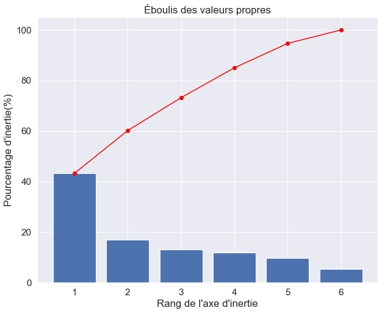

```python
# Définition de la fonction pour le graphique Éboulis des valeurs propres

def display_scree_plot(pca):
    scree = pca.explained_variance_ratio_*100
    plt.bar(np.arange(len(scree))+1, scree)
    plt.plot(np.arange(len(scree))+1, scree.cumsum(), c="red", marker='o')
    plt.xlabel("Rang de l'axe d'inertie")
    plt.ylabel("Pourcentage d'inertie(%)")
    plt.title("Éboulis des valeurs propres")
    plt.show(block=False)

# Nombre de composants souhaités
n_comp = 6

# Calcul des composantes principales
pca = decomposition.PCA(n_components=n_comp)
pca.fit(X_scaled)

display_scree_plot(pca)
plt.show()
```

```python
# Proportion de variance expliquée
pca.explained_variance_ratio_
```

```
array([0.43201658, 0.16957859, 0.13018767, 0.11823888, 0.09669064,
       0.05328764])
```

Cet éboulis indique que l'axe F1 et F2 ont une grande inertie de presque 60%. On va s'intéresser aux axes F1 et F2.

### Cercle de corrélation

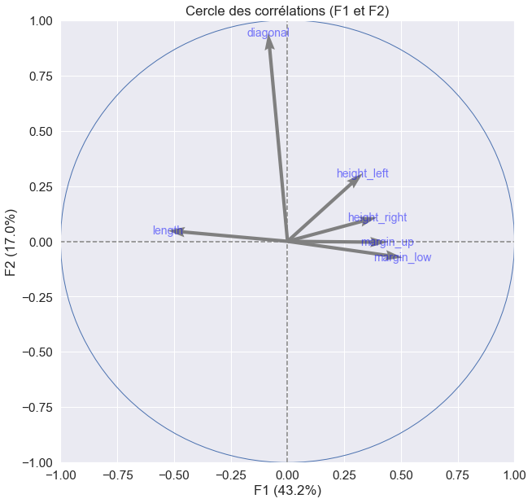

```python
from matplotlib.collections import LineCollection

# Définition de la fonction pour le graphique Cercle de corrélation


def display_circles(pcs, n_comp, pca, axis_ranks, labels=None, label_rotation=0, lims=None):
    for d1, d2 in axis_ranks:  # On affiche les 3 premiers plans factoriels, donc les 6 premières composantes
        if d2 < n_comp:

            # initialisation de la figure
            fig, ax = plt.subplots(figsize=(10, 10))

            # détermination des limites du graphique
            if lims is not None:
                xmin, xmax, ymin, ymax = lims
            elif pcs.shape[1] < 30:
                xmin, xmax, ymin, ymax = -1, 1, -1, 1
            else:
                xmin, xmax, ymin, ymax = min(pcs[d1, :]), max(
                    pcs[d1, :]), min(pcs[d2, :]), max(pcs[d2, :])

            # affichage des flèches
            # s'il y a plus de 30 flèches, on n'affiche pas le triangle à leur extrémité
            if pcs.shape[1] < 30:
                plt.quiver(np.zeros(pcs.shape[1]), np.zeros(pcs.shape[1]),
                           pcs[d1, :], pcs[d2, :],
                           angles='xy', scale_units='xy', scale=1, color="grey")
            else:
                lines = [[[0, 0], [x, y]] for x, y in pcs[[d1, d2]].T]
                ax.add_collection(LineCollection(
                    lines, axes=ax, alpha=.1, color='black'))

            # affichage des noms des variables
            if labels is not None:
                for i, (x, y) in enumerate(pcs[[d1, d2]].T):
                    if x >= xmin and x <= xmax and y >= ymin and y <= ymax:
                        plt.text(x, y, labels[i], fontsize='14', ha='center',
                                 va='center', rotation=label_rotation, color="blue", alpha=0.5)

            # affichage du cercle
            circle = plt.Circle((0, 0), 1, facecolor='none', edgecolor='b')
            plt.gca().add_artist(circle)

            # définition des limites du graphique
            plt.xlim(xmin, xmax)
            plt.ylim(ymin, ymax)

            # affichage des lignes horizontales et verticales
            plt.plot([-1, 1], [0, 0], color='grey', ls='--')
            plt.plot([0, 0], [-1, 1], color='grey', ls='--')

            # nom des axes, avec le pourcentage d'inertie expliqué
            plt.xlabel('F{} ({}%)'.format(
                d1+1, round(100*pca.explained_variance_ratio_[d1], 1)))
            plt.ylabel('F{} ({}%)'.format(
                d2+1, round(100*pca.explained_variance_ratio_[d2], 1)))

            plt.title("Cercle des corrélations (F{} et F{})".format(d1+1, d2+1))
            plt.show(block=False)


# Cercle des corrélations

n_comp = 2
pcs = pca.components_
display_circles(pcs, n_comp, pca, [(0, 1)],
                labels=np.array(billets.columns[1:7]))

plt.show()
```

### Projection des individus sur le plan factoriel selon le type de billet

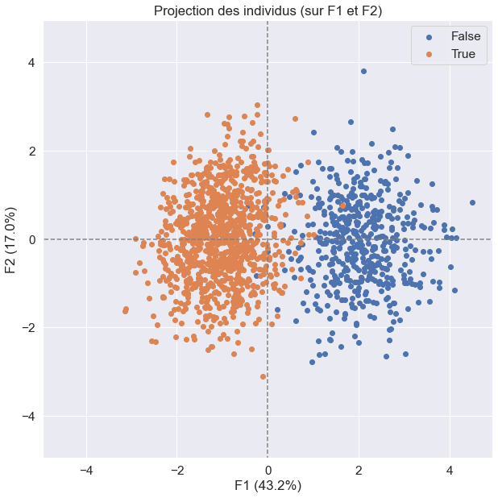

```python
# Définition de la fonction pour le graphique Projection des individus sur les plans factoriels

def display_factorial_planes(X_projected, n_comp, pca, axis_ranks, labels=None, alpha=1, illustrative_var=None):
    for d1, d2 in axis_ranks:
        if d2 < n_comp:

            # initialisation de la figure
            fig = plt.figure(figsize=(10, 10))

            # affichage des points
            if illustrative_var is None:
                plt.scatter(X_projected[:, d1],
                            X_projected[:, d2], alpha=alpha)
            else:
                illustrative_var = np.array(illustrative_var)
                for value in np.unique(illustrative_var):
                    selected = np.where(illustrative_var == value)
                    plt.scatter(
                        X_projected[selected, d1], X_projected[selected, d2], alpha=alpha, label=value)
                plt.legend()

            # affichage des labels des points
            if labels is not None:
                for i, (x, y) in enumerate(X_projected[:, [d1, d2]]):
                    plt.text(x, y, labels[i],
                             fontsize='14', ha='center', va='center')

            # détermination des limites du graphique
            boundary = np.max(np.abs(X_projected[:, [d1, d2]])) * 1.1
            plt.xlim([-boundary, boundary])
            plt.ylim([-boundary, boundary])

            # affichage des lignes horizontales et verticales
            plt.plot([-100, 100], [0, 0], color='grey', ls='--')
            plt.plot([0, 0], [-100, 100], color='grey', ls='--')

            # nom des axes, avec le pourcentage d'inertie expliqué
            plt.xlabel('F{} ({}%)'.format(
                d1+1, round(100*pca.explained_variance_ratio_[d1], 1)))
            plt.ylabel('F{} ({}%)'.format(
                d2+1, round(100*pca.explained_variance_ratio_[d2], 1)))

            plt.title(
                "Projection des individus (sur F{} et F{})".format(d1+1, d2+1))
            plt.show(block=False)


# Projection des individus sur F1 et F2
X_projected = pca.transform(X_scaled)
display_factorial_planes(X_projected, n_comp, pca, [
                         (0, 1)], illustrative_var=billets.is_genuine)
```

On peut observer que la projection des individus sur le premier plan factoriel, qui distingue plutôt bien les vrai et faux billets.

## Kmeans Analyse

### Récupération des clusters attribués à chaque individu

```python
# Classification méthode Kmeans
km = KMeans(2, random_state=10)
km.fit(X_scaled)

# Récupération des clusters attribués à chaque individu
billets["Clusters"] = km.labels_
billets
```

|  | is_genuine | diagonal | height_left | height_right | margin_low | margin_up | length | Clusters |
| --- | --- | --- | --- | --- | --- | --- | --- | --- |
| 0 | True | 171.81 | 104.86 | 104.95 | 4.52 | 2.89 | 112.83 | 0 |
| 1 | True | 171.46 | 103.36 | 103.66 | 3.77 | 2.99 | 113.09 | 1 |
| 2 | True | 172.69 | 104.48 | 103.50 | 4.40 | 2.94 | 113.16 | 1 |
| 3 | True | 171.36 | 103.91 | 103.94 | 3.62 | 3.01 | 113.51 | 1 |
| 4 | True | 171.73 | 104.28 | 103.46 | 4.04 | 3.48 | 112.54 | 1 |
| ... | ... | ... | ... | ... | ... | ... | ... | ... |
| 1495 | False | 171.75 | 104.38 | 104.17 | 4.42 | 3.09 | 111.28 | 0 |
| 1496 | False | 172.19 | 104.63 | 104.44 | 5.27 | 3.37 | 110.97 | 0 |
| 1497 | False | 171.80 | 104.01 | 104.12 | 5.51 | 3.36 | 111.95 | 0 |
| 1498 | False | 172.06 | 104.28 | 104.06 | 5.17 | 3.46 | 112.25 | 0 |
| 1499 | False | 171.47 | 104.15 | 103.82 | 4.63 | 3.37 | 112.07 | 0 |

1500 rows × 8 columns

### Comparaison de moyen des variables entre clusters et le type de billet

```python
billets.groupby("Clusters").mean().drop("is_genuine", axis=1)
```

| Clusters | diagonal | height_left | height_right | margin_low | margin_up | length |
| --- | --- | --- | --- | --- | --- | --- |
| 0 | 171.899153 | 104.200383 | 104.152520 | 5.221734 | 3.351734 | 111.630847 |
| 1 | 171.987729 | 103.945129 | 103.805588 | 4.117968 | 3.052540 | 113.196066 |

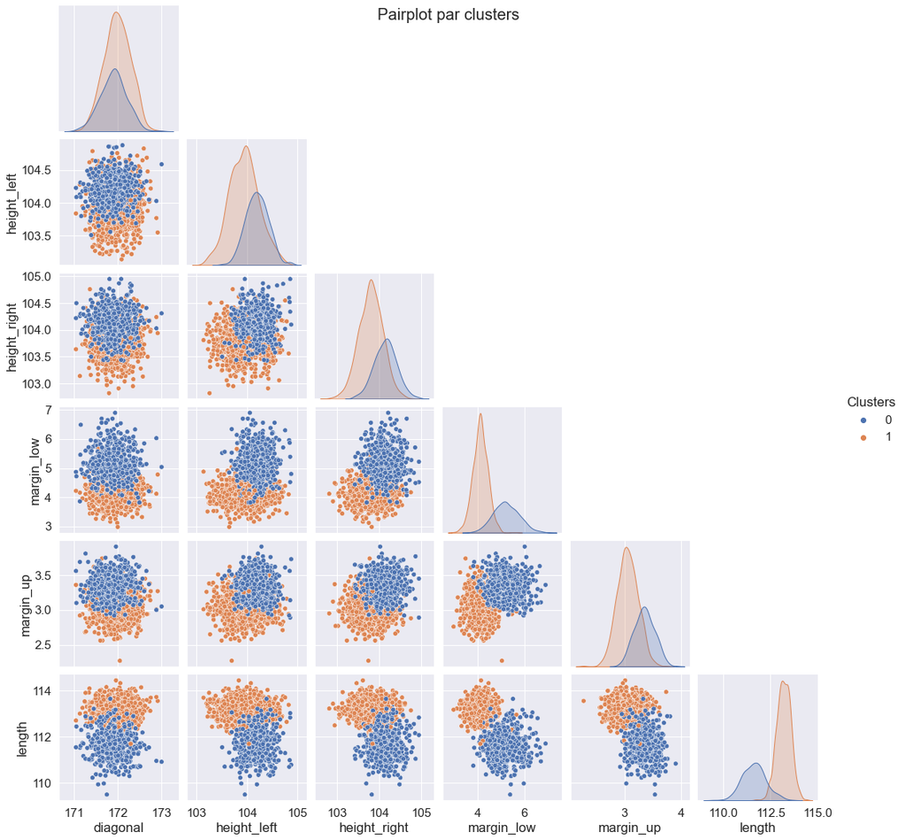

```python
sns.pairplot(billets.drop("is_genuine", axis=1), hue='Clusters',
             corner=True).fig.suptitle('Pairplot par clusters')

plt.show()
```

```python
billets.groupby("is_genuine").mean().drop("Clusters", axis=1)
```

| is_genuine | diagonal | height_left | height_right | margin_low | margin_up | length |
| --- | --- | --- | --- | --- | --- | --- |
| False | 171.90116 | 104.19034 | 104.14362 | 5.21622 | 3.35016 | 111.63064 |
| True | 171.98708 | 103.94913 | 103.80865 | 4.11631 | 3.05213 | 113.20243 |

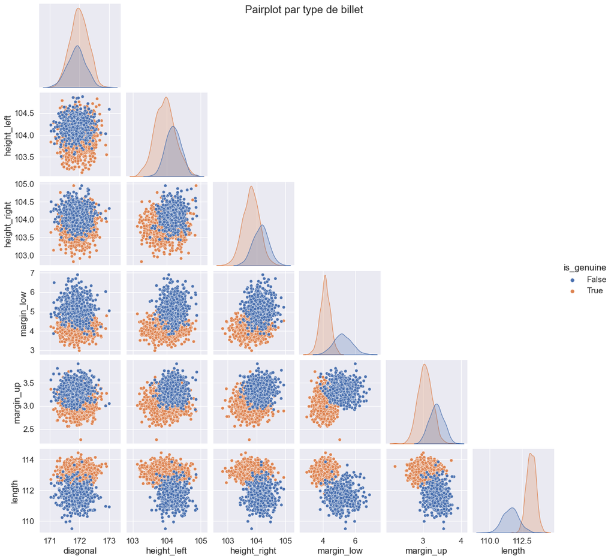

```python
sns.pairplot(billets.drop("Clusters", axis=1), hue='is_genuine',
             corner=True).fig.suptitle('Pairplot par type de billet')

plt.show()
```

Selon ce comparaison de moyen de chaque variable , les groupes créés par KMeans sont très proches de la distinction de vrai et faux billets, donc, cluster 0 correspond à faux billet, et cluster 1 sont de vrai.

### Projection des individus sur le premier plan factoriel par clusters

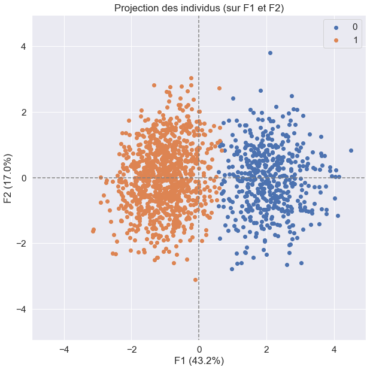

```python
# Affichage du clustering par projection des individus sur le premier plan factoriel

display_factorial_planes(X_projected, n_comp, pca, [
                         (0, 1)], illustrative_var=billets.Clusters)
```

Visuellement, sur le graphique, les clusters sont aussi très similaire par rapport à la distinction de vrai et faux billets, donc, cluster 0 correspond à faux billet, et cluster 1 est de vrai.

### Matrice de confusion Kmeans

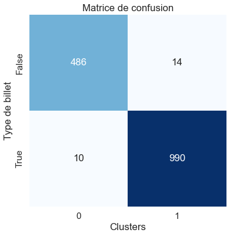

```python
conf_matrix = pd.crosstab(billets.is_genuine, km.labels_)

# Representation graphique de notre matrice de confusion
sns.set(rc={'figure.figsize': (6, 6)}, font_scale=1.4)
sns.heatmap(conf_matrix, annot = True, fmt='', cmap='Blues', cbar=False)

plt.title('Matrice de confusion')
plt.xlabel('Clusters')
plt.ylabel('Type de billet')
plt.show()
```

On fait une analyse des nombres de faux via une matrix de confusion, en comparant les deux clusters avec la distinction original des vrais et faux billets. Donc, ici, nous avons 10 vrais billets détectés comme des faux billets (cluster 0), et 14 faux billets détectés comme des vrais billets (cluster 1). On va ensuite ajouter les données de test pour voir si on peut bien détecter des faux billets à l'aide de KMeans.

### Tester les billets inconnus

#### Importation des données de test

```python
# Importation des données de test
b = pd.read_csv(
    'Desktop/Openclassrooms/P10_Shibin_YANG/billets_production.csv', sep=',')
b
```

|  | diagonal | height_left | height_right | margin_low | margin_up | length | id |
| --- | --- | --- | --- | --- | --- | --- | --- |
| 0 | 171.76 | 104.01 | 103.54 | 5.21 | 3.30 | 111.42 | A_1 |
| 1 | 171.87 | 104.17 | 104.13 | 6.00 | 3.31 | 112.09 | A_2 |
| 2 | 172.00 | 104.58 | 104.29 | 4.99 | 3.39 | 111.57 | A_3 |
| 3 | 172.49 | 104.55 | 104.34 | 4.44 | 3.03 | 113.20 | A_4 |
| 4 | 171.65 | 103.63 | 103.56 | 3.77 | 3.16 | 113.33 | A_5 |

#### Combiner les données inconnues avec les données d'origine

```python
# Combiner les données inconnues avec les données d'origine avant centré et réduit
billets_plus = pd.concat([billets.drop("Clusters", axis = 1), b])
billets_plus
```

|  | is_genuine | diagonal | height_left | height_right | margin_low | margin_up | length | id |
| --- | --- | --- | --- | --- | --- | --- | --- | --- |
| 0 | True | 171.81 | 104.86 | 104.95 | 4.52 | 2.89 | 112.83 | NaN |
| 1 | True | 171.46 | 103.36 | 103.66 | 3.77 | 2.99 | 113.09 | NaN |
| 2 | True | 172.69 | 104.48 | 103.50 | 4.40 | 2.94 | 113.16 | NaN |
| 3 | True | 171.36 | 103.91 | 103.94 | 3.62 | 3.01 | 113.51 | NaN |
| 4 | True | 171.73 | 104.28 | 103.46 | 4.04 | 3.48 | 112.54 | NaN |
| ... | ... | ... | ... | ... | ... | ... | ... | ... |
| 0 | NaN | 171.76 | 104.01 | 103.54 | 5.21 | 3.30 | 111.42 | A_1 |
| 1 | NaN | 171.87 | 104.17 | 104.13 | 6.00 | 3.31 | 112.09 | A_2 |
| 2 | NaN | 172.00 | 104.58 | 104.29 | 4.99 | 3.39 | 111.57 | A_3 |
| 3 | NaN | 172.49 | 104.55 | 104.34 | 4.44 | 3.03 | 113.20 | A_4 |
| 4 | NaN | 171.65 | 103.63 | 103.56 | 3.77 | 3.16 | 113.33 | A_5 |

1505 rows × 8 columns

#### Préparation des données de test (centrées et réduites)

```python
# Préparation des données de test pour l'ACP
z = billets_plus.drop(columns = ["is_genuine", "id"]).values

# Centrage et Réduction avec les données d'origine pour ne biaise pas le résultat
std_scale = preprocessing.StandardScaler().fit(z)
z_scaled = std_scale.transform(z)
z_scaled
```

```
array([[-0.4865586 ,  2.76923391,  3.16170796,  0.05410626, -1.13061318,
         0.17500507],
       [-1.63390724, -2.23576629, -0.79994111, -1.08170256, -0.69868709,
         0.47301405],
       [ 2.39820372,  1.50130053, -1.29130844, -0.12762315, -0.91465013,
         0.55324723],
       ...,
       [ 0.13628781,  1.83496721,  1.13481774,  0.76587979,  1.02901727,
        -1.26919229],
       [ 1.74257592,  1.7348672 ,  1.28837003, -0.06704668, -0.52591665,
         0.59909477],
       [-1.01106084, -1.33486626, -1.10704569, -1.08170256,  0.03558727,
         0.74809926]])
```

#### Projection des individus d'origine par clusters, et les individus inconnus sur le plan factoriel

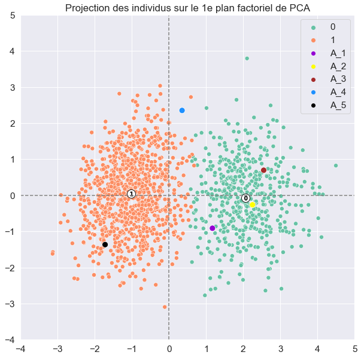

```python
# Projection des individus d'origine, en ajoutant les individus inconnus sur F1 et F2
# Comparer avec les clusters

z_projected = pca.transform(z_scaled[-5:])

clusters = km.labels_

sns.set(rc={'figure.figsize': (10, 10)}, font_scale=1.4)
sns.scatterplot(x=X_projected[:, 0], y=X_projected[:,
                1], hue=clusters, s=50, palette='Set2')
sns.scatterplot(x=z_projected[:, 0], y=z_projected[:, 1], palette=['darkviolet', 'yellow',
                'brown', 'dodgerblue', 'black'], hue=billets_plus.id[-5:], s=100)
plt.legend()
plt.title("Projection des individus sur le 1e plan factoriel de PCA")

# Affichage des positions des centres de classes
centroids = km.cluster_centers_
centroids_projected = pca.transform(centroids)
plt.scatter(centroids_projected[:, 0], centroids_projected[:, 1],
            marker="o", c="white", alpha=1, s=200, edgecolor="k")
for i, c in enumerate(centroids_projected):
    plt.scatter(c[0], c[1], marker="$%d$" % i, alpha=1, s=50, edgecolor="k")

# affichage des lignes horizontales et verticales
plt.plot([-4, 5], [0, 0], color='grey', ls='--')
plt.plot([0, 0], [-4, 5], color='grey', ls='--')

# définition des limites du graphique
plt.xlim([-4, 5])
plt.ylim([-4, 5])

plt.show(block=False)
```

On peut quasiment d'être sûr que les billets 'A_1', 'A_2', 'A_3' sont dans le cluster 0, certainement ils sont des faux billets, les billets 'A_4', 'A_5' sont dans le cluster 1, certainement ils sont des vrais billets. On va essayer de chercher pour chaque individu de test, le plus proche de centoid des deux clusters.

#### Prédiction par Kmeans

```python
# Prédiction par Kmeans
y_kmeans = km.predict(z_scaled[-5:])
verif = pd.DataFrame(y_kmeans, index=billets_plus.id[-5:],
                     columns=['Clusters']).reset_index()
verif
```

|  | id | Clusters |
| --- | --- | --- |
| 0 | A_1 | 0 |
| 1 | A_2 | 0 |
| 2 | A_3 | 0 |
| 3 | A_4 | 1 |
| 4 | A_5 | 1 |

#### Calcul de la distance entre chaque billet inconnu et le centre des clusters

```python
# Vérification de la projection de centroids
centroids_projected
```

```
array([[ 2.06704432, -0.07421998, -0.09135135, -0.08668897, -0.13922759,
        -0.04720493],
       [-1.0211693 ,  0.03666644,  0.04512975,  0.04282642,  0.06878176,
         0.02332036]])
```

```python
# Vérification de centroids
centroids
```

```
array([[-0.19432338,  0.57071311,  0.71336493,  1.12003987,  0.86417597,
        -1.20083284],
       [ 0.09600039, -0.28194592, -0.35241933, -0.55332647, -0.42692359,
         0.59324013]])
```

```python
from scipy.spatial import distance_matrix

# Vérification des billets à l'aide de distance entre chaque individu et les deux centroids
dist_mat = pd.DataFrame(distance_matrix(z_scaled[-5:], centroids), index=billets_plus.id[-5:], columns=[
                        'Centroid_0', 'Centroid_1']).reset_index()
dist_mat
```

|  | id | Centroid_0 | Centroid_1 |
| --- | --- | --- | --- |
| 0 | A_1 | 2.065007 | 3.045863 |
| 1 | A_2 | 1.310503 | 3.557206 |
| 2 | A_3 | 1.429174 | 3.744802 |
| 3 | A_4 | 3.466805 | 3.117248 |
| 4 | A_5 | 4.116400 | 1.849531 |

On a donc le résultat, les billets 'A_1', 'A_2', 'A_3' sont des faux billets, car ils sont plus proche du centroid de cluster 0, et les billets 'A_4', 'A_5' sont des vrais, ils sont proche du centroid de cluster 1.

On va créer un model pour détecter les billets inconnus, en utilisant la distance minimale entre chaque billets inconnus et les controids des clusters pour réaliser la prédiction.

## Script de modèle de détection Kmeans

```python
def verif_billets_model_kmeans(csv):
    bills = pd.read_csv(csv)
    id_bills = bills["id"]
    billets_plus = pd.concat([billets.drop("Clusters", axis = 1), bills])
    bills_val = billets_plus.drop(columns = ["is_genuine", "id"]).values
    test = preprocessing.StandardScaler().fit(bills_val[-5:])
    test_scaled = test.transform(bills_val[-5:])
    dist = pd.DataFrame(distance_matrix(test_scaled, centroids), index=bills["id"], columns=[
                        'Centroid_0', 'Centroid_1']).reset_index()
    predictions = dist["Centroid_0"] > dist["Centroid_1"]

    for i in range(len(bills)):
        print("billets {} : c'est un vrai billet = {}".format(
            id_bills[i], predictions[i]))
```

```python
verif_billets_model_kmeans("Desktop/Openclassrooms/P10_Shibin_YANG/billets_production.csv")
```

```
billets A_1 : c'est un vrai billet = False
billets A_2 : c'est un vrai billet = False
billets A_3 : c'est un vrai billet = False
billets A_4 : c'est un vrai billet = True
billets A_5 : c'est un vrai billet = True
```

```python
verif_billets_model_kmeans("Desktop/Openclassrooms/P10_Shibin_YANG/billets_test.csv")
```

```
billets B_1 : c'est un vrai billet = True
billets B_2 : c'est un vrai billet = False
billets B_3 : c'est un vrai billet = True
billets B_4 : c'est un vrai billet = False
billets B_5 : c'est un vrai billet = False
```

Pour être sûr de ce résultat, on va encore essayer les autres méthodes.

# Régression logistique

## Régression logistique avec la librairie Sklearn

### Séparation des données d'entraînement et de test

Pour appliquer cette méthode, nous allons séparer le jeu de données en training set et testing set. J'ai mis la répartition classique 80/20 entre training et testing set, c'est-à-dire que je vais fixer les données d'entrainement à 1200 individus, et les données de test à 300 individus.

```python
# Création de modèle d'entraînement
model_logit_reg = linear_model.LogisticRegression()

X = billets.loc[:, "diagonal":"length"]
Y = billets.is_genuine
```

```python
Xtrain, Xtest, Ytrain, Ytest = train_test_split(
    X, Y, train_size=0.8, random_state=0)
```

```python
Xtest.shape
```

```
(300, 6)
```

```python
Xtrain.shape
```

```
(1200, 6)
```

### Création de modèle régression logistique

```python
model_logit_reg.fit(Xtrain, Ytrain)
```

```
LogisticRegression()
```

```python
print("Le coefficient de détermination du model: {} %".format(
    round((model_logit_reg.score(Xtrain, Ytrain)*100), 2)))
```

```
Le coefficient de détermination du model: 98.92 %
```

### Évaluation du modèle avec les données de test

```python
# "accuracy_score" utilisé pour évaluer le score de classification de la prédiction (nos cas : Vrai ou faux)
# Si on calcul le taux de prédiction correcte sur les données de test

Y_predict = model_logit_reg.predict(Xtest)
print("Le taux de prédiction correcte sur les données de test = {}%".format(
    round((accuracy_score(Ytest, Y_predict)*100), 2)))
```

```
Le taux de prédiction correcte sur les données de test = 99.67%
```

```python
# "r2_score" calcule le coefficient de détermination, utilisé pour les valeurs continues (nombres réels)
# Si on veut vraiment utiliser "r2_score", faut transformer les valeurs prédiction en nombre réels
# Par contre, comme on le transforme en int, le résultat va être influencé
# Par example, on calcul le taux de prédiction correcte sur les données de test

Y_predict_transfor = Y_predict.astype(int)
print("Le coefficient de détermination sur les données de test = {}%".format(
    round((r2_score(Ytest, Y_predict_transfor)*100), 2)))
```

```
Le coefficient de détermination sur les données de test = 98.48%
```

### Matrice de confusion régression logistique

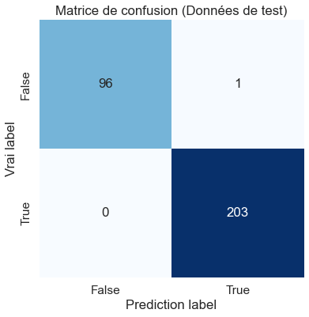

```python
# Matrix de confusion sur les données de test
conf_matrix = pd.DataFrame(confusion_matrix(Ytest, Y_predict), index=[
                           'False', 'True'], columns=['False', 'True'])

# Representation graphique de notre matrice de confusion
sns.set(rc={'figure.figsize': (6, 6)}, font_scale=1.4)
sns.heatmap(conf_matrix, annot=True, fmt='', cmap='Blues', cbar=False)

plt.title('Matrice de confusion (Données de test)')
plt.xlabel('Prediction label')
plt.ylabel('Vrai label')
plt.show()
```

En appliquant la méthode de régression logistique avec les données de test, selon la matrice de confusion, nous avons 0 vrai billet détecté comme de faux billet, et 1 faux billet détecté comme de vrai billet. On a le coefficient de déterminationle qui est égale 0.99, cela signifie que le taux de prédiction d'un billet sera correcte s'éleve à 99%,

### Coefficient régression logistique

```python
pd.DataFrame(np.concatenate([model_logit_reg.intercept_.reshape(-1, 1), model_logit_reg.coef_],
             axis=1), index=["coef"], columns=["constante"]+list(X.columns)).T
```

|  | coef |
| --- | --- |
| constante | -0.017673 |
| diagonal | -0.046297 |
| height_left | -1.547336 |
| height_right | -2.071765 |
| margin_low | -3.400010 |
| margin_up | -3.288560 |
| length | 3.651367 |

## Script de modèle de détection régression logistique - 1

```python
def verif_model_logiR1(csv):
    bills = pd.read_csv(csv)
    id_bills = bills["id"]
    bills_val = bills.loc[:, "diagonal":"length"]
    predictions = model_logit_reg.predict_proba(bills_val)
    for i in range(len(bills)):
        print("billets {} : probabilité que le billet soit vrai = {}%".format(
            id_bills[i], round(((predictions[i][1])*100), 2)))
```

```python
verif_model_logiR1("Desktop/Openclassrooms/P10_Shibin_YANG/billets_production.csv")
```

```
billets A_1 : probabilité que le billet soit vrai = 0.58%
billets A_2 : probabilité que le billet soit vrai = 0.1%
billets A_3 : probabilité que le billet soit vrai = 0.14%
billets A_4 : probabilité que le billet soit vrai = 91.13%
billets A_5 : probabilité que le billet soit vrai = 99.96%
```

On va donc détecter les billets inconnus, on a donc le résultat, les billets 'A_1', 'A_2', 'A_3' sont des faux billets, et les billets 'A_4', 'A_5' sont des vrais.

```python
verif_model_logiR1("Desktop/Openclassrooms/P10_Shibin_YANG/billets_test.csv")
```

```
billets B_1 : probabilité que le billet soit vrai = 98.87%
billets B_2 : probabilité que le billet soit vrai = 0.92%
billets B_3 : probabilité que le billet soit vrai = 99.9%
billets B_4 : probabilité que le billet soit vrai = 0.02%
billets B_5 : probabilité que le billet soit vrai = 1.38%
```

## Régression logistique avec la librairie Statsmodels

### Séparation des données d'entraînement et de test

```python
x = billets.loc[:, "diagonal":"length"]
y = billets.is_genuine

# Séparation des données d'entrainement et des données de test
x_train, x_test, y_train, y_test = train_test_split(
    x, y, train_size=0.8, random_state=5)
```

### Création de modèle régression logistique

```python
# Création de model
x_train = sm.add_constant(x_train)
model = sm.Logit(y_train, x_train)
result = model.fit()
print(result.summary())
```

```
Optimization terminated successfully.
         Current function value: 0.024266
         Iterations 14
                           Logit Regression Results
==============================================================================
Dep. Variable:             is_genuine   No. Observations:                 1200
Model:                          Logit   Df Residuals:                     1193
Method:                           MLE   Df Model:                            6
Date:                Tue, 01 Mar 2022   Pseudo R-squ.:                  0.9616
Time:                        15:51:04   Log-Likelihood:                -29.119
converged:                       True   LL-Null:                       -758.87
Covariance Type:            nonrobust   LLR p-value:                     0.000
================================================================================
                   coef    std err          z      P>|z|      [0.025      0.975]
--------------------------------------------------------------------------------
const         -187.8962    290.180     -0.648      0.517    -756.638     380.846
diagonal        -0.4808      1.342     -0.358      0.720      -3.112       2.150
height_left     -1.3173      1.237     -1.065      0.287      -3.742       1.108
height_right    -2.5304      1.237     -2.045      0.041      -4.955      -0.106
margin_low      -6.6440      1.291     -5.147      0.000      -9.174      -4.114
margin_up      -11.0990      2.767     -4.011      0.000     -16.523      -5.675
length           6.5440      1.144      5.720      0.000       4.302       8.786
================================================================================

Possibly complete quasi-separation: A fraction 0.57 of observations can be
perfectly predicted. This might indicate that there is complete
quasi-separation. In this case some parameters will not be identified.
```

### Évaluation du modèle avec les données de test

```python
# Tester la prédiction avec les données de test
x_test = sm.add_constant(x_test)
y_predict = result.predict(x_test)
```

```python
# Le coefficient de détermination sur les données de test
print("Le coefficient de détermination sur les données de test = {}%".format(
    round((r2_score(y_test, y_predict)*100), 2)))
```

```
Le coefficient de détermination sur les données de test = 95.35%
```

```python
# Si on veut savoir le score de prédiction après arrondir le résultat de prédiction
# Par contre, comme on le transforme en int, le résultat va être influencé

prediction = list(map(round, y_predict))
print("Le taux de prédiction correcte sur les données de test = {}%".format(
    round((accuracy_score(y_test, prediction)*100), 2)))
```

```
Le taux de prédiction correcte sur les données de test = 98.33%
```

### Matrice de confusion régression logistique

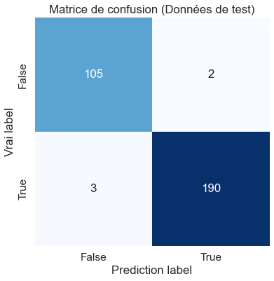

```python
# Matrix de confusion sur les données de test
conf_matrix = pd.DataFrame(confusion_matrix(y_test, prediction), index=[
                           'False', 'True'], columns=['False', 'True'])

# Representation graphique de notre matrice de confusion
sns.set(rc={'figure.figsize': (6, 6)}, font_scale=1.4)
sns.heatmap(conf_matrix, annot=True, fmt='', cmap='Blues', cbar=False)

plt.title('Matrice de confusion (Données de test)')
plt.xlabel('Prediction label')
plt.ylabel('Vrai label')
plt.show()
```

J'essaye d'appliquer la régression logistique avec un autre librairie Statsmodels, on a R2 : le coefficient de détermination qui est à peu près 0.96, 95% sur les données de test, c'est aussi pas mal. Selon la matrice de confusion, nous avons 3 vrais billets détectés comme des faux billets, et 2 faux billets détectés comme des vrais billets.

## Script de modèle de détection régression logistique - 2

```python
def verif_model_logiR2(csv):
    bills = pd.read_csv(csv)
    id_bills = bills["id"]
    bills_val = bills.loc[:, "diagonal":"length"]
    bills_val = sm.add_constant(bills_val)
    predictions = result.predict(bills_val)
    for i in range(len(bills)):
        print("billets {} : probabilité que le billet soit vrai = {}%".format(
            id_bills[i], round(((predictions[i])*100), 2)))
```

```python
verif_model_logiR2("Desktop/Openclassrooms/P10_Shibin_YANG/billets_production.csv")
```

```
billets A_1 : probabilité que le billet soit vrai = 0.0%
billets A_2 : probabilité que le billet soit vrai = 0.0%
billets A_3 : probabilité que le billet soit vrai = 0.0%
billets A_4 : probabilité que le billet soit vrai = 99.38%
billets A_5 : probabilité que le billet soit vrai = 100.0%
```

On va aussi détecter les billets inconnus, on a donc le même résultat, les billets 'A_1', 'A_2', 'A_3' sont des faux billets, et les billets 'A_4', 'A_5' sont des vrais.

On va essayer encore la méthode KNN pour vérifier si la détection de ce model est correcte.

```python
verif_model_logiR2("Desktop/Openclassrooms/P10_Shibin_YANG/billets_test.csv")
```

```
billets B_1 : probabilité que le billet soit vrai = 99.93%
billets B_2 : probabilité que le billet soit vrai = 0.01%
billets B_3 : probabilité que le billet soit vrai = 100.0%
billets B_4 : probabilité que le billet soit vrai = 0.0%
billets B_5 : probabilité que le billet soit vrai = 0.07%
```

# K Nearest Neighbors (K-NN)

## Séparation des données d'entraînement et de test

On va maintenant essayer la méthode K-NN, c’est un algorithme qui peut servir autant pour la classification que pour la régression. Il est surnommé « nearest neighbors » (plus proches voisins, en français) car le principe de ce modèle consiste en effet à choisir les k données les plus proches du point étudié afin d’en prédire sa valeur.

Pour l'appliquer, nous allons séparer le jeu de données en training set et testing set comme précédent. J'ai mis la répartition classique 80/20 entre training et testing set.

```python
x = billets.select_dtypes(np.number).drop(["Clusters"], axis=1)
y = billets.is_genuine

xtrain, xtest, ytrain, ytest = train_test_split(
    x, y, train_size=0.8, random_state=10)
```

```python
xtest.shape
```

```
(300, 6)
```

```python
xtrain.shape
```

```
(1200, 6)
```

## Calcul le nombre optimal de K

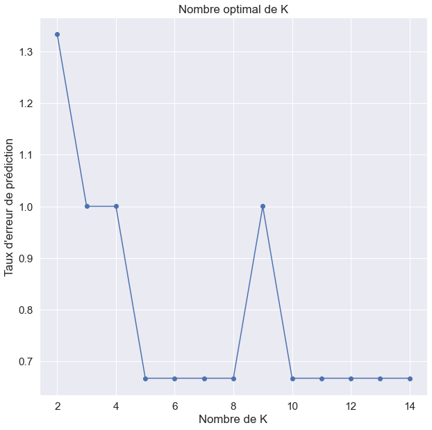

```python
errors = []
for k in range(2,15):
    knn = neighbors.KNeighborsClassifier(k)
    errors.append(100*(1 - knn.fit(xtrain, ytrain).score(xtest, ytest)))
plt.figure(figsize=(10, 10))
plt.plot(range(2,15), errors, 'o-')
plt.title('Nombre optimal de K')
plt.ylabel("Taux d'erreur de prédiction")
plt.xlabel('Nombre de K')
plt.show()
```

Le k (nombre de voisins) est l'hyper-paramètre que l’on va chercher à optimiser pour minimiser l’erreur sur les données test. Pour trouver le k optimal, on va simplement tester le modèle pour tous les k de 2 à 15, mesurer l’erreur test et afficher la performance en fonction de k.

Comme on peut le voir, le k-NN le plus performant est celui pour lequel k = 5. On connaît donc notre classifieur final optimal : 5-NN. Ce qui veut dire que c'est celui qui classifie le mieux les données.

## Création de modèle 5-NN

```python
# On récupère le classifieur le plus performant
knn = neighbors.KNeighborsClassifier(5)
knn.fit(xtrain, ytrain)
```

```
KNeighborsClassifier()
```

```python
# Le précision de la prédiction Knn
print("Le précision de la prédiction du model: {} %".format(
    round((knn.score(xtrain, ytrain)*100), 2)))
```

```
Le précision de la prédiction du model: 99.25 %
```

## Évaluation du modèle avec les données de test

```python
# On récupère les prédictions sur les données test
yprediction = knn.predict(xtest)
```

```python
# On calcul le taux d'erreur de prédiction sur les données de test
error = 1 - knn.score(xtest, ytest)
print("Le taux d'erreur de prédiction sur les données de test: {} %".format(round((error*100), 2)))
```

```
Le taux d'erreur de prédiction sur les données de test: 0.67 %
```

```python
print("Le taux de prédiction correcte sur les données de test = {}%".format(
    round((accuracy_score(ytest, yprediction)*100), 2)))
```

```
Le taux de prédiction correcte sur les données de test = 99.33%
```

```python
print(classification_report(ytest, yprediction))
```

```
              precision    recall  f1-score   support

       False       1.00      0.98      0.99       105
        True       0.99      1.00      0.99       195

    accuracy                           0.99       300
   macro avg       0.99      0.99      0.99       300
weighted avg       0.99      0.99      0.99       300
```

## Matrice de confusion K-NN

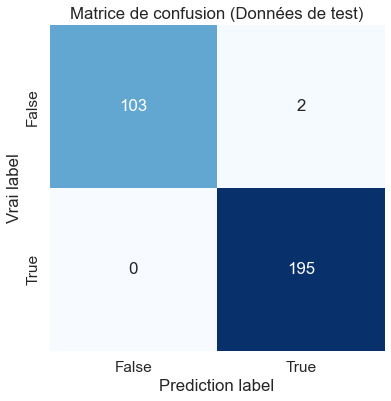

```python
# Matrix de confusion sur les données de test
conf_matrix = pd.DataFrame(confusion_matrix(ytest, yprediction), index=[
                           'False', 'True'], columns=['False', 'True'])

# Representation graphique de notre matrice de confusion
sns.set(rc={'figure.figsize': (6, 6)}, font_scale=1.4)
sns.heatmap(conf_matrix, annot=True, fmt='', cmap='Blues', cbar=False)

plt.title('Matrice de confusion (Données de test)')
plt.xlabel('Prediction label')
plt.ylabel('Vrai label')
```

En appliquant la méthode de 5-NN, selon la matrice de confusion, pour les données de test, 0 vrai billet détecté comme de faux billet, et 2 faux billets détectés comme des vrais billets, le taux de prédiction d'un billet sera correcte s'éleve aussi à 99%.

## Script de modèle de détection K-NN

```python
def verif_model_knn(csv):
    bills = pd.read_csv(csv)
    id_bills = bills["id"]
    bills_val = bills.loc[:, "diagonal":"length"]
    predictions = knn.predict(bills_val)
    for i in range(len(bills)):
        print("billets {} : c'est un vrai billet = {}".format(
            id_bills[i], (predictions[i])))
```

```python
verif_model_knn("Desktop/Openclassrooms/P10_Shibin_YANG/billets_production.csv")
```

```
billets A_1 : c'est un vrai billet = False
billets A_2 : c'est un vrai billet = False
billets A_3 : c'est un vrai billet = False
billets A_4 : c'est un vrai billet = True
billets A_5 : c'est un vrai billet = True
```

```python
verif_model_knn("Desktop/Openclassrooms/P10_Shibin_YANG/billets_test.csv")
```

```
billets B_1 : c'est un vrai billet = True
billets B_2 : c'est un vrai billet = False
billets B_3 : c'est un vrai billet = True
billets B_4 : c'est un vrai billet = False
billets B_5 : c'est un vrai billet = False
```

On va détecter les billets inconnus, on a donc le même résultat, les billets 'A_1', 'A_2', 'A_3' sont des faux billets, et les billets 'A_4', 'A_5' sont des vrais. On peut aussi voir la probabilité de prédiction de chaque billet.

```python
def verif_model_knn_proba(csv):
    bills = pd.read_csv(csv)
    id_bills = bills["id"]
    bills_val = bills.loc[:, "diagonal":"length"]
    predictions = knn.predict_proba(bills_val)
    for i in range(len(bills)):
        print("billets {} : probabilité que le billet soit vrai = {}%".format(
            id_bills[i], round(((predictions[i][1])*100), 2)))
```

```python
verif_model_knn_proba("Desktop/Openclassrooms/P10_Shibin_YANG/billets_production.csv")
```

```
billets A_1 : probabilité que le billet soit vrai = 0.0%
billets A_2 : probabilité que le billet soit vrai = 0.0%
billets A_3 : probabilité que le billet soit vrai = 0.0%
billets A_4 : probabilité que le billet soit vrai = 100.0%
billets A_5 : probabilité que le billet soit vrai = 100.0%
```

```python
verif_model_knn_proba("Desktop/Openclassrooms/P10_Shibin_YANG/billets_test.csv")
```

```
billets B_1 : probabilité que le billet soit vrai = 100.0%
billets B_2 : probabilité que le billet soit vrai = 0.0%
billets B_3 : probabilité que le billet soit vrai = 100.0%
billets B_4 : probabilité que le billet soit vrai = 0.0%
billets B_5 : probabilité que le billet soit vrai = 0.0%
```